# ALSM: Chapter 4

Simultaneous Inferences and Other Topics in Regression Analysis

Darshan Patel

12/27/2020

```r
library(tidyverse)
library(latex2exp)
library(gridExtra)
library(wesanderson)
library(broom)
theme_set(theme_minimal())
```

### Problem 1:

When joint confidence intervals for $\beta_0$ and $\beta_1$ are developed by the Bonferroni method with a family confidence coefficient of $90$ percent, does this imply that $10$ percent of the time the confidence interval for $\beta_0$ will be incorrect? That $5$ percent of the time the confidence interval for $\beta_0$ will be incorrect and $5$ percent of the time that for $\beta_1$ will be incorrect? Discuss.

### Problem 2:

Refer to Problem 2.1. Suppose the student combines the two confidence intervals into a confidence set. What can you say about the family confidence coefficient for this set?

Answer: The family confidence coefficient of this set is $90$ percent. The $\alpha$ values for estimating $\beta_0$ and $\beta_1$ are $.05$ each and so
$$P(\overline{A}_1 \cap \overline{A}_2) \geq 1 - 2\alpha = 1 - 2(.05) = .9$$

### Problem 3:

Refer to *Copier maintenance* Problem 1.20.

1. Will $b_0 $ and $b_1$ tend to err in the same direction or in opposite directions here? Explain.

```r
copier = read.csv('CH01PR20.txt', sep = '', header = FALSE,
                  col.names = c('y', 'x'),
                  colClasses = c('numeric', 'numeric'))

mean(copier$x)
```

[1] 5.111111

Since the mean of $X$ is positive, $b_0$ and $b_1$ will tend to err in the opposite direction here, meaning they’re negatively correlated.

2. Obtain Bonferroni joint confidence intervals for $\beta_0$ and $\beta_1$, using a $95$ percent family confidence coefficient.

Answer:

```r
lm.fit_manual = function(X, Y){
  b1 = sum((X - mean(X))*(Y - mean(Y))) / (sum((X - mean(X))^2))
  b0 = mean(Y) - b1*mean(X)
  return(c(b0, b1))
}

bonferroni.joint.ci = function(data, alpha){

  model = lm.fit_manual(data$x, data$y)
  B = qt(1 - (alpha/4), nrow(data)-2)

  pred = model[1] + model[2]*data$x
  MSE = sum((data$y - pred)^2)/(nrow(data)-2)

  s2_b1 = MSE / sum((data$x - mean(data$x))^2)
  s2_b0 = MSE * ((1/nrow(data)) + (mean(data$x)^2/(sum((data$x - mean(data$x))^2))))


  b0_lower = round(model[1] - (B*sqrt(s2_b0)), 3)
  b0_upper = round(model[1] + (B*sqrt(s2_b0)), 3)

  b1_lower = round(model[2] - (B*sqrt(s2_b1)), 3)
  b1_upper = round(model[2] + (B*sqrt(s2_b1)), 3)

  paste("At the alpha level of", alpha, "the Bonferroni joint confidence intervals are:",
        b0_lower, "<= b0 <=", b0_upper, "and",
        b1_lower, "<= b1 <=", b1_upper, sep = ' ')
}

bonferroni.joint.ci(copier, 0.05)
```

[1] “At the alpha level of 0.05 the Bonferroni joint confidence intervals are: -7.093 <= b0 <= 5.932 and 13.913 <= b1 <= 16.157”

3. A consultant has suggested that $\beta_0$ should be $0$ and $\beta_1$ should equal $14.0$. Do your joint confidence intervals in part (b) support this view?

Answer: The joint confidence intervals in part (b) support this view. Both $\beta_0$ and $\beta_1$ fall in the two interval estimates.

### Problem 4:

Refer to *Airfreight breakage* Problem 1.21.

1. Will $b_0$ and $b_1$ tend to err in the same direction or in opposite directions here? Explain.

Answer:

```r
airfreight = read.csv('CH01PR21.txt', sep = '', header = FALSE,
                  col.names = c('y', 'x'),
                  colClasses = c('numeric', 'numeric'))

mean(airfreight$x)
```

[1] 1

Since the mean of $X$ is positive, $b_0$ and $b_1$ will tend to err in the opposite directions as they’re negatively correlated.

2. Obtain Bonferroni joint confidence intervals for $\beta_0$ and $\beta_1$, using a $99$ percent family confidence coefficient. Interpret your confidence intervals.

Answer:

```r
bonferroni.joint.ci(airfreight, .01)
```

[1] “At the alpha level of 0.01 the Bonferroni joint confidence intervals are: 7.658 <= b0 <= 12.742 and 2.202 <= b1 <= 5.798”

At a family confidence of $99$ percent, $\beta_0$ is between $7.658$ and $12.742$, and $\beta_1$ is between $2.202$ and $5.798$.

### Problem 5:

Refer to *Plastic hardness* Problem 1.22.

1. Obtain Bonferroni join confidence intervals for $\beta_0$ and $\beta_1$, using a $90$ percent family confidence coefficient. Interpret your confidence intervals.

Answer:

```r
plastic = read.csv('CH01PR22.txt', sep = '', header = FALSE,
                  col.names = c('y', 'x'),
                  colClasses = c('numeric', 'numeric'))

bonferroni.joint.ci(plastic, .1)
```

[1] “At the alpha level of 0.1 the Bonferroni joint confidence intervals are: 162.901 <= b0 <= 174.299 and 1.84 <= b1 <= 2.228”

At a family confidence of $90$ percent, $\beta_0$ is between $162.901$ and $174.299$, and $\beta_1$ is between $1.84$ and $2.228$.

2. Are $b_0$ and $b_1$ positively or negatively correlated here? Is this reflected in your joint confidence intervals in part (a)?

Answer:

```r
mean(plastic$x)
```

[1] 28

$b_0$ and $b_1$ are negatively correlated here, as the mean of $X$ is positive. This is reflected in the coefficient estimates. The estimates for $\beta_0$ are high compared to the estimates for $\beta_1$.

3. What is the meaning of the family confidence coefficient in part (a)?

Answer: A family confidence of $90$ percent implies that both estimates, $b_0$ and $b_1$, will fall within the intervals determined $90$ percent of the time. In the other $10$ percent of times, either one or both estimates will be outside of the confidence limits.

### Problem 6:

Refer to *Muscle mass* Problem 1.27.

1. Obtain Bonferroni joint confidence intervals for $\beta_0$ and $\beta_1$, using a $99$ percent family confidence coefficient. Interpret your confidence intervals.

Answer:

```r
muscle = read.csv('CH01PR27.txt', sep = '', header = FALSE,
                  col.names = c('y', 'x'),
                  colClasses = c('numeric', 'numeric'))

bonferroni.joint.ci(muscle, .01)
```

[1] “At the alpha level of 0.01 the Bonferroni joint confidence intervals are: 140.26 <= b0 <= 172.434 and -1.453 <= b1 <= -0.927”

At a family confidence of $99$ percent, $\beta_0$ is between $140.26$ and $172.434$, and $\beta_1$ is between $-1.453$ and $-0.927$.

2. Will $b_0$ and $b_1$ tend to err in the same direction or in opposite directions here? Explain.

Answer:

```r
mean(muscle$x)
```

[1] 59.98333

Since the mean of $X$ is positive, $b_0$ and $b_1$ will err in opposite directions, as they are negatively correlated.

3. A researcher has suggested that $\beta_0$ should equal approximately $160$ and that $\beta_1$ should be between $-1.9$ and $-1.5$. Do the joint confidence intervals in part (a) support this expectation?

Answer: The joint confidence intervals in part (a) do not support this expectation.

### Problem 7:

Refer to *Copier maintenance* Problem 1.20.

1. Estimate the expected number of minutes spent when there are $3$, $5$, and $7$ copiers to be serviced, respectively. Use interval estimates with a $90$ percent family confidence coefficient based on the Working-Hotelling procedure.

Answer:

```r
working.hotelling.reg.band = function(data, alpha, Xh){

  model = lm.fit_manual(data$x, data$y)
  preds = model[1] + model[2]*data$x
  MSE = sum((data$y - preds)^2) / (nrow(data)-2)

  W = sqrt(2 * qf(1 - alpha, 2, nrow(data)-2))
  Yh = model[1] + model[2]*Xh
  s2_Yh = MSE * ((1/nrow(data)) + (((Xh - mean(data$x))^2)/ sum((data$x - mean(data$x))^2)))

  Yh_lower = round(Yh - (W*sqrt(s2_Yh)), 3)
  Yh_upper = round(Yh + (W*sqrt(s2_Yh)), 3)

  paste("Using a", alpha*100, "percent alpha value and the Working-Hotelling procedure, Y_h is estimated to lie between", Yh_lower, "and", Yh_upper, sep = ' ')
}

working.hotelling.reg.band(copier, .1, 3)
```

[1] “Using a 10 percent alpha value and the Working-Hotelling procedure, Y_h is estimated to lie between 40.833 and 48.219”

```r
working.hotelling.reg.band(copier, .1, 5)
```

[1] “Using a 10 percent alpha value and the Working-Hotelling procedure, Y_h is estimated to lie between 71.664 and 77.528”

```r
working.hotelling.reg.band(copier, .1, 7)
```

[1] “Using a 10 percent alpha value and the Working-Hotelling procedure, Y_h is estimated to lie between 101.113 and 108.22”

2. Two service calls for preventive maintenance are scheduled in which the numbers of copiers to be serviced are $4$ and $7$, respectively. A family of prediction intervals for the times to be spent on these calls is desired with a $90$ percent family confidence coefficient. Which procedure, Scheffé or Bonferroni, will provide tighter prediction limits here?

Answer:

```r
scheffe.coef = function(alpha, g, n){
  paste("The Scheffé procedure gives an estimate of",
        round(sqrt(g*qf(1 - alpha, g, n - 2)), 3),
        "for the multiple of the estimated standard deviation",
        sep = ' ')
}
bonferroni.coef = function(alpha, g, n){
  paste("The Bonferroni procedure gives an estimate of",
        round(qt(1 - (alpha/(2*g)), n-2), 3),
        "for the multiple of the estimated standard deviation",
        sep = ' ')
}

scheffe.coef(.1, 2, nrow(copier))
```

[1] “The Scheffé procedure gives an estimate of 2.205 for the multiple of the estimated standard deviation”

```r
bonferroni.coef(.1, 2, nrow(copier))
```

[1] “The Bonferroni procedure gives an estimate of 2.017 for the multiple of the estimated standard deviation”

The Bonferroni procedure provides the tighter prediction limits here.

3. Obtain the family of prediction intervals required in part (b), using the most efficient procedure.

Answer:

```r
family.pred.interval = function(data, alpha, g, Xh,
                                method = c("Scheffe", "Bonferroni", "best")){

  model = lm.fit_manual(data$x, data$y)
  preds = model[1] + model[2]*data$x
  MSE = sum((data$y - preds)^2) / (nrow(data)-2)

  Yh = model[1] + model[2]*Xh
  s2_pred = MSE * ((1/nrow(data)) +
                     (((Xh - mean(data$x))^2)/sum((data$x - mean(data$x))^2)))

  S = sqrt(g * qf(1 - alpha, g, nrow(data)-2))
  s2_pred_S = MSE * (1 + (1/nrow(data)) +
                     (((Xh - mean(data$x))^2)/sum((data$x - mean(data$x))^2)))
  B = qt(1 - (alpha / (2 * g)), nrow(data)-2)
  s2_pred_B = MSE * ((1/nrow(data)) +
                     (((Xh - mean(data$x))^2)/sum((data$x - mean(data$x))^2)))

  if(method == "Scheffe"){
    multiplier = S
    s2_pred = s2_pred_S
  }
  else if(method == "Bonferroni"){
    multiplier = B
    s2_pred = s2_pred_B
  }
  else{
    if(S > B){
      method = "Bonferroni (best of two)"
      multiplier = B
      s2_pred = s2_pred_B
    }
    else{
      method = "Scheffe (best of two)"
      multiplier = S
      s2_pred = s2_pred_S
    }
  }

  lower_bound = round(Yh - (multiplier*sqrt(s2_pred)), 3)
  upper_bound = round(Yh + (multiplier*sqrt(s2_pred)), 3)

  paste("Using a", alpha*100, "percent alpha value and the", method,
        "procedure, Y_h is estimated to lie between", lower_bound,
        "and", upper_bound, sep = ' ')
}

family.pred.interval(copier, .1, 2, 4, "Bonferroni")
```

[1] “Using a 10 percent alpha value and the Bonferroni procedure, Y_h is estimated to lie between 56.671 and 62.451”

```r
family.pred.interval(copier, .1, 2, 7, "Bonferroni")
```

[1] “Using a 10 percent alpha value and the Bonferroni procedure, Y_h is estimated to lie between 101.416 and 107.917”

### Problem 8:

Refer to *Airfreight breakage* Problem 1.21.

1. It is desired to obtain interval estimates of the mean number of broken ampules when there are $0$, $1$, and $2$ transfers for a shipment, using a $95$ percent family confidence coefficient. Obtain the desired confidence intervals, using the Working-Hotelling procedure.

Answer:

```r
working.hotelling.reg.band(airfreight, .05, 0)
```

[1] “Using a 5 percent alpha value and the Working-Hotelling procedure, Y_h is estimated to lie between 8.219 and 12.181”

```r
working.hotelling.reg.band(airfreight, .05, 1)
```

[1] “Using a 5 percent alpha value and the Working-Hotelling procedure, Y_h is estimated to lie between 12.799 and 15.601”

```r
working.hotelling.reg.band(airfreight, .05, 2)
```

[1] “Using a 5 percent alpha value and the Working-Hotelling procedure, Y_h is estimated to lie between 16.219 and 20.181”

2. Are the confidence intervals obtained in part (a) more efficient than Bonferroni intervals here? Explain.

Answer:

```r
family.pred.interval(airfreight, .05, 3, 0, "Bonferroni")
```

[1] “Using a 5 percent alpha value and the Bonferroni procedure, Y_h is estimated to lie between 8.2 and 12.2”

```r
family.pred.interval(airfreight, .05, 3, 1, "Bonferroni")
```

[1] “Using a 5 percent alpha value and the Bonferroni procedure, Y_h is estimated to lie between 12.785 and 15.615”

```r
family.pred.interval(airfreight, .05, 3, 2, "Bonferroni")
```

[1] “Using a 5 percent alpha value and the Bonferroni procedure, Y_h is estimated to lie between 16.2 and 20.2”

The confidence intervals obtained in part (a) are more efficient than Bonferroni intervals, since the width of the interval is tighter when using the Working-Hotelling procedure.

3. The next three shipments will make $0$, $1$, and $2$ transfers, respectively. Obtain prediction intervals for the number of broken ampules for each of these three shipments, using the Scheffé procedure and a $95$ percent family confidence coefficient.

Answer:

```r
family.pred.interval(airfreight, .05, 3, 0, "Scheffe")
```

[1] “Using a 5 percent alpha value and the Scheffe procedure, Y_h is estimated to lie between 4.525 and 15.875”

```r
family.pred.interval(airfreight, .05, 3, 1, "Scheffe")
```

[1] “Using a 5 percent alpha value and the Scheffe procedure, Y_h is estimated to lie between 8.767 and 19.633”

```r
family.pred.interval(airfreight, .05, 3, 2, "Scheffe")
```

[1] “Using a 5 percent alpha value and the Scheffe procedure, Y_h is estimated to lie between 12.525 and 23.875”

4. Would the Bonferroni procedure have been more efficient in developing the prediction intervals in part (c)? Explain.

Answer:

```r
bonferroni.coef(.05, 3, nrow(airfreight))
```

[1] “The Bonferroni procedure gives an estimate of 3.016 for the multiple of the estimated standard deviation”

```r
scheffe.coef(.05, 3, nrow(airfreight))
```

[1] “The Scheffé procedure gives an estimate of 3.493 for the multiple of the estimated standard deviation”

The Bonferroni procedure would have been more efficient in developing the prediction intervals, compared to the ones made in part (c). The widths of the limits are larger when using the Scheffé procedure.

### Problem 9:

Refer to *Plastic hardness* Problem 1.22.

1. Management wishes to obtain interval estimates of the mean hardness when the elapsed time is $20$, $30$, and $40$ hours, respectively. Calculate the desired confidence intervals using the Bonferroni procedure and a $90$ percent family confidence coefficient. What is the meaning of the family confidence coefficient here?

Answer:

```r
family.pred.interval(plastic, .1, 3, 20, "Bonferroni")
```

[1] “Using a 10 percent alpha value and the Bonferroni procedure, Y_h is estimated to lie between 206.728 and 211.847”

```r
family.pred.interval(plastic, .1, 3, 30, "Bonferroni")
```

[1] “Using a 10 percent alpha value and the Bonferroni procedure, Y_h is estimated to lie between 227.676 and 231.586”

```r
family.pred.interval(plastic, .1, 3, 40, "Bonferroni")
```

[1] “Using a 10 percent alpha value and the Bonferroni procedure, Y_h is estimated to lie between 246.782 and 253.168”

The family confidence coefficient here means that there is a $90$ percent probability that $Y$ will lie in these limits for $X = 20$, $30$ and $40$ hours, respectively.

2. Is the Bonferroni procedure employed in part (a) the most efficient one that could be employed here? Explain.

Answer:

```r
working.hotelling.coef = function(alpha, n){
  paste("The Working-Hotelling procedure gives an estimate of",
        round(sqrt(2 * qf(1 - alpha, 2, n-2)), 3),
        "for the multiple of the estimated standard deviation",
        sep = ' ')
}
working.hotelling.coef(.1, nrow(plastic))
```

[1] “The Working-Hotelling procedure gives an estimate of 2.335 for the multiple of the estimated standard deviation”

```r
bonferroni.coef(.1, 3, nrow(plastic))
```

[1] “The Bonferroni procedure gives an estimate of 2.36 for the multiple of the estimated standard deviation”

The Bonferroni procedure is not the most efficient one to use in this scenario as it gives a wider width for the confidence band compared to the Working-Hotelling procedure.

3. The next two test items will be measured after $30$ and $40$ hours of elapsed time, respectively. Predict the hardness for each of these two items, using the most efficient procedure and a $90$ percent family confidence coefficient.

Answer:

```r
family.pred.interval(plastic, .1, 2, 30, "best")
```

[1] “Using a 10 percent alpha value and the Bonferroni (best of two) procedure, Y_h is estimated to lie between 227.854 and 231.408”

```r
family.pred.interval(plastic, .1, 2, 40, "best")
```

[1] “Using a 10 percent alpha value and the Bonferroni (best of two) procedure, Y_h is estimated to lie between 247.073 and 252.877”

Between the Bonferroni and Scheffe procedures, the Bonferroni procedure returns the more efficient interval estimates.

### Problem 10:

Refer to *Muscle mass* Problem 1.27.

1. The nutritionist is particularly interested in the mean muscle mass for women aged $45$, $55$ and $65$. Obtain joint confidence intervals for the means of interest using the Working-Hotelling procedure and a $95$ percent family confidence coefficient.

Answer:

```r
working.hotelling.reg.band(muscle, .05, 45)
```

[1] “Using a 5 percent alpha value and the Working-Hotelling procedure, Y_h is estimated to lie between 98.489 and 107.104”

```r
working.hotelling.reg.band(muscle, .05, 55)
```

[1] “Using a 5 percent alpha value and the Working-Hotelling procedure, Y_h is estimated to lie between 88.015 and 93.778”

```r
working.hotelling.reg.band(muscle, .05, 65)
```

[1] “Using a 5 percent alpha value and the Working-Hotelling procedure, Y_h is estimated to lie between 76.112 and 81.881”

2. Is the Working-Hotelling procedure the most efficient one to be employed in part (a)? Explain.

Answer:

```r
working.hotelling.coef(.05, nrow(muscle))
```

[1] “The Working-Hotelling procedure gives an estimate of 2.512 for the multiple of the estimated standard deviation”

```r
bonferroni.coef(.05, 3, nrow(muscle))
```

[1] “The Bonferroni procedure gives an estimate of 2.465 for the multiple of the estimated standard deviation”

The Bonferroni procedure provides a tighter width on the confidence interval than the Working-Hotelling procedure.

3. Three additional women aged $48$, $59$ and $74$ have contacted the nutritionist. Predict the muscle mass for each of these three women using the Bonferroni procedure and a $95$ percent family confidence coefficient.

Answer:

```r
family.pred.interval(muscle, .05, 3, 48, "Bonferroni")
```

[1] “Using a 5 percent alpha value and the Bonferroni procedure, Y_h is estimated to lie between 95.503 and 102.951”

```r
family.pred.interval(muscle, .05, 3, 59, "Bonferroni")
```

[1] “Using a 5 percent alpha value and the Bonferroni procedure, Y_h is estimated to lie between 83.526 and 88.747”

```r
family.pred.interval(muscle, .05, 3, 74, "Bonferroni")
```

[1] “Using a 5 percent alpha value and the Bonferroni procedure, Y_h is estimated to lie between 64.227 and 72.347”

4. Subsequently, the nutritionist wishes to predict the muscle mass for a fourth woman aged $64$, with a family confidence coefficient of $95$ percent for the four predictions. Will the three prediction intervals in part (c) have to be recalculated? Would this also be true if the Scheffé procedure had been used in constructing the prediction intervals?

Answer: Under this new situation, the three prediction intervals in part (b) will have to be recalculated as $X=64$ is not one of the $X_h$s predicted for. In addition, if the Scheffé procedure is to be used, the prediction intervals in part (c) would have to be recalculated as well, since the multiplier for the standard deviation is from a different distribution.

### Problem 11:

A behavioral scientist said, “I am never sure whether the regression line goes through the origin. Hence I will not use such a model.” Comment.

Answer: If a regression line is destined to go through the origin, the model will attempt to fixate the $b_0$ estimate to be as close to the origin as could be possible, given the other points in the data.

### Problem 12:

*Typographical errors.* A firm specializing in technical manuscripts has a random sample of recent orders, where $X$ is the number of galleys for a manuscript and $Y$ is the total dollar cost of correcting typographical errors. Since $Y$ involves variable costs only, an analyst wished to determine whether regression-through-the-origin model is appropriate for studying the relationship between the two variables.

1. Fit the regression model prescribed above and state the estimated regression function.

Answer:

```r
typo_errors = read.csv('CH04PR12.txt', sep = '', header = FALSE,
                       col.names = c('y', 'x'),
                       colClasses = c('numeric', 'numeric'))

lm.fit.origin_manual = function(x, y){
  b1 = sum(x*y)/sum(x^2)
  return(b1)
}

model = round(lm.fit.origin_manual(typo_errors$x, typo_errors$y), 3)
paste("Y = ", model, "x", sep = '')
```

[1] “Y = 18.028x”

2. Plot the estimated regression function and the data. Does a linear regression function thought the origin appear to provide a good fit here? Comment.

Answer:

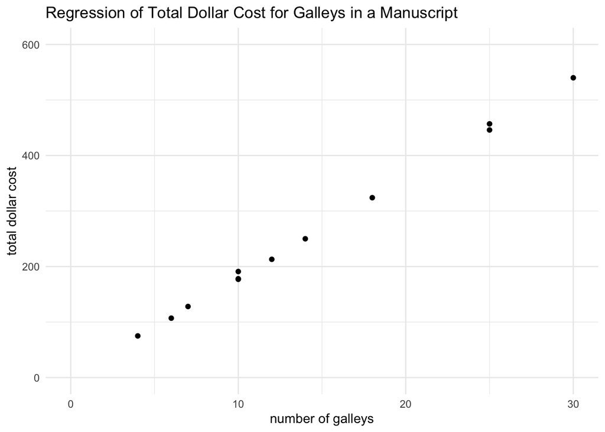

```r
typo_errors %>%
  ggplot(aes(x,y)) +
  geom_point() +
  geom_abline(intercept = model[1], slope = model[2],
              color = "cadetblue") +
  scale_x_continuous(limits = c(0, 30)) +
  scale_y_continuous(limits = c(0, 600)) +
  labs(x = "number of galleys",
       y = "total dollar cost",
       title = "Regression of Total Dollar Cost for Galleys in a Manuscript")
```

By showing the origin on the plot, it is apparent that a linear regression function through the origin provides a good fit to the data.

3. In estimating costs of handling prospective orders, management has used a standard of $\$17.50$ per galley for the cost of correcting typographical errors. Test whether or not this standard should be revised; use $\alpha = .02$. State the alternatives, decision rules and conclusion.

Answer: Let the null hypothesis be that $\beta_1 = \$17.50$ and the alternative hypothesis be that $\beta_1 \neq \$17.50$. Then

```r
b1.origin.test = function(data, beta1 = 0, alpha = .01){

  model = lm.fit.origin_manual(data$x, data$y)
  pred = model*data$x
  MSE = sum((data$y - pred)^2) / (nrow(data)-1)
  s2_b1 = MSE / sum((data$x)^2)
  t_ast = round((beta1 - model) /sqrt(s2_b1), 3)
  t = qt(1 - (alpha/2), nrow(data)-1)

  if(abs(t_ast) > t){
    paste("At the alpha level of", alpha, "the test statistic is", round(t_ast, 3),
          "and the decision is to reject H_0.", sep = ' ')
  }
  else{
    paste("At the alpha level of", alpha, "the test statistic is", round(t_ast, 3),
          "and the decision is to fail to reject H_0.", sep = ' ')
  }
}

b1.origin.test(typo_errors, beta1 = 17.50, alpha = .02)
```

[1] “At the alpha level of 0.02 the test statistic is -6.647 and the decision is to reject H_0.”

It can be said with $98$ percent confidence that $b_1$ is not $\$17.50$.

4. Obtain a prediction interval for the correction cost on a forthcoming job involving $10$ galleys. Use a confidence coefficient of $98$ percent.

Answer:

```r
Yhat_pred_interval_origin = function(data, Xhat, alpha = 0.01){

  model = lm.fit.origin_manual(data$x, data$y)
  pred = model*data$x
  Yhat = model*Xhat
  MSE = sum((data$y - pred)^2) / (nrow(data)-1)
  s2_Yhat_new = MSE * (1 + (Xhat^2/sum(data$x^2)))
  t = qt(1 - (alpha/2), nrow(data)-1)
  error = t*sqrt(s2_Yhat_new)
  lower = round(Yhat - error, 3)
  upper = round(Yhat + error, 3)
  return(c(lower, upper))
}

Yhat_pred_interval_origin(typo_errors, 10, .02)
```

[1] 167.844 192.722

### Problem 13:

Refer to *Typographical errors* Problem 4.12.

1. Obtain the residuals $e_i$. Do they sum to zero? Plot the residuals against the fitted values $\hat{Y}_i$. What conclusions can be drawn from your plot?

Answer:

```r
model = lm.fit.origin_manual(typo_errors$x, typo_errors$y)
typo_errors_zero_model = typo_errors %>%
  mutate(preds = model*x,
         resids = y - preds)
typo_errors_zero_model$resids %>% sum
```

[1] 3.159876

The residuals do not sum to zero.

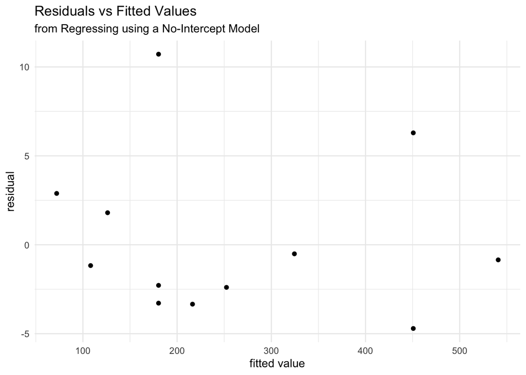

```r
typo_errors_zero_model %>%
  ggplot(aes(preds, resids)) +
  geom_point() +
  labs(x = "fitted value",
       y = "residual",
       title = "Residuals vs Fitted Values",
       subtitle = "from Regressing using a No-Intercept Model")
```

2. Conduct a formal test for lack of fit of linear regression through the origin; use $\alpha = .01$. State the alternatives, decision rule and conclusion. What the $P$-value of the test?

Answer: Let the null hypothesis be that $E[Y] = \beta_1X$ and the alternative hypothesis that $E[Y] \neq \beta_1X$. Then

```r
lack.of.fit.origin.test = function(data, alpha = 0.05, pval = FALSE){

  X = data$x
  Y = data$y
  Y_bars = data.frame(x = sort(unique(X)))
  mean_vec = c()
  for(i in Y_bars$x){
    temp_mean = mean(data[data$x == i, "y"])
    mean_vec = c(mean_vec, temp_mean)
  }
  Y_bars$ybars = mean_vec
  SSPE= 0
  for(i in Y_bars$x){
    temp_Y = data[data$x == i, "y"]
    SSPE = SSPE + sum((temp_Y - Y_bars[Y_bars$x == i, "ybars"])^2)
  }
  df_F = nrow(data) - length(unique(X))

  model = lm.fit.origin_manual(X, Y)
  Ypreds = model*X
  SSE_R = sum((Ypreds - Y)^2)
  df_R = nrow(data) - 1

  F_ast = round(((SSE_R - SSPE) / (df_R - df_F))/(SSPE / df_F), 3)

  if(pval){
    print(paste("P value:", round(pf(F_ast, length(unique(X)) - 1,
                                     nrow(data) - length(unique(X)),
                                     lower.tail = FALSE), 3),
          sep = ' '))
  }

  if(F_ast < qf(1 - alpha, length(unique(X)) - 1, nrow(data) - length(unique(X)),
                lower.tail = FALSE)){
    paste("At the alpha level of", alpha, "the test statistic is", F_ast, "and the null hypothesis is failed to be rejected. There is no sufficent evidence that the regression function is linear.", sep = ' ')
  }
  else{
    paste("At the alpha level of", alpha, "the test statistic is", F_ast, "and the null hypothesis is rejected. There is evidence that the regression function is not linear.", sep = ' ')
  }
}
lack.of.fit.origin.test(typo_errors, 0.01, TRUE)
```

[1] “P value: 0.997” [1] “At the alpha level of 0.01 the test statistic is 0.084 and the null hypothesis is failed to be rejected. There is no sufficent evidence that the regression function is linear.”

```r
?pf
```

### Problem 14:

Refer to *Grade point average* Problem 1.19. Assume that linear regression through the origin model is appropriate.

1. Fit regression model and state the estimated regression function.

Answer:

```r
gpa = read.csv('CH01PR19.txt', sep = '', header = FALSE,
               col.names = c('y', 'x'),
               colClasses = c('numeric', 'numeric'))

model = round(lm.fit.origin_manual(gpa$x, gpa$y), 3)
paste("Y = ", model, "X", sep = '')
```

[1] “Y = 0.122X”

2. Estimate $\beta_1$ with a $95$ percent confidence interval. Interpret your interval estimate.

Answer:

```r
b1.origin.conf.int = function(data, alpha = 0.01){

  model = lm.fit.origin_manual(data$x, data$y)
  pred = model*data$x
  MSE = sum((data$y - pred)^2) / (nrow(data)-1)
  s2_b1 = MSE/sum(data$x^2)
  t = qt(1 - (alpha/2), nrow(data)-1)
  error = t*sqrt(s2_b1)
  lower = round(model - error, 3)
  upper = round(model + error, 3)
  return(c(lower, upper))
}

b1.origin.conf.int(gpa, .05)
```

[1] 0.116 0.127

$b_1$ is estimated to lie between $0.116$ and $0.127$, with $95$ percent confidence.

3. Estimate the mean freshman GPA for students whose ACT test score is $30$. Use a $95$ percent confidence interval.

Answer:

```r
exp.Yh.origin.conf.int = function(data, Xh, alpha = 0.01){

  model = lm.fit.origin_manual(data$x, data$y)
  pred = model*data$x
  Yh = model*Xh
  MSE = sum((data$y - pred)^2) / (nrow(data)-1)
  s2_Yh = MSE * ((Xh^2/sum(data$x^2)))
  t = qt(1 - (alpha/2), nrow(data)-1)
  error = t*sqrt(s2_Yh)
  lower = round(Yh - error, 3)
  upper = round(Yh + error, 3)
  return(c(lower, upper))
}

exp.Yh.origin.conf.int(gpa, 30, .05)
```

[1] 3.493 3.806

### Problem 15:

Refer to *Grade point average* Problem 4.14.

1. Plot the fitted regression line and the data. Does the linear regression function through the origin appear to be a good fit here?

Answer:

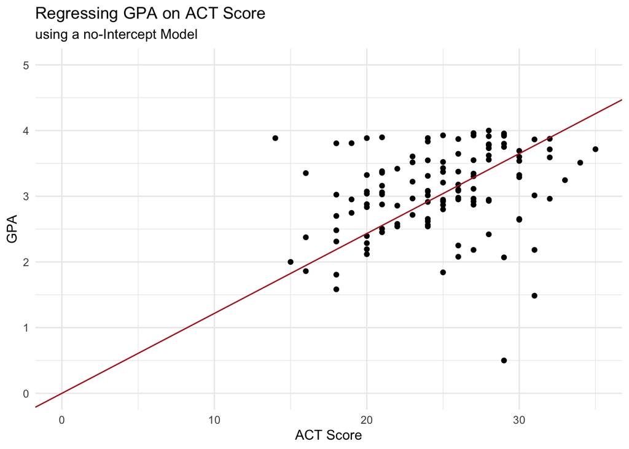

```r
model = lm.fit.origin_manual(gpa$x, gpa$y)

gpa %>%
  ggplot(aes(x,y)) +
  geom_point() +
  geom_abline(intercept = 0, slope = model, color = "firebrick") +
  scale_x_continuous(limits = c(0, 35)) +
  scale_y_continuous(limits = c(0, 5)) +
  labs(x = "ACT Score",
       y = "GPA",
       title = "Regressing GPA on ACT Score",
       subtitle = "using a no-Intercept Model")
```

The linear regression function through the origin does not appear to be a good fit here.

2. Obtain the residuals $e_i$. Do they sum to zero? Plot the residuals against the fitted values $\hat{Y}_i$. What conclusions can be drawn from your plot?

Answer:

```r
gpa_no_intercept_model = gpa %>%
  mutate(preds = model*x,
         resids = y - preds)

gpa_no_intercept_model$resids %>% sum
```

[1] 7.9715

The residuals of the no-intercept model do not sum to zero.

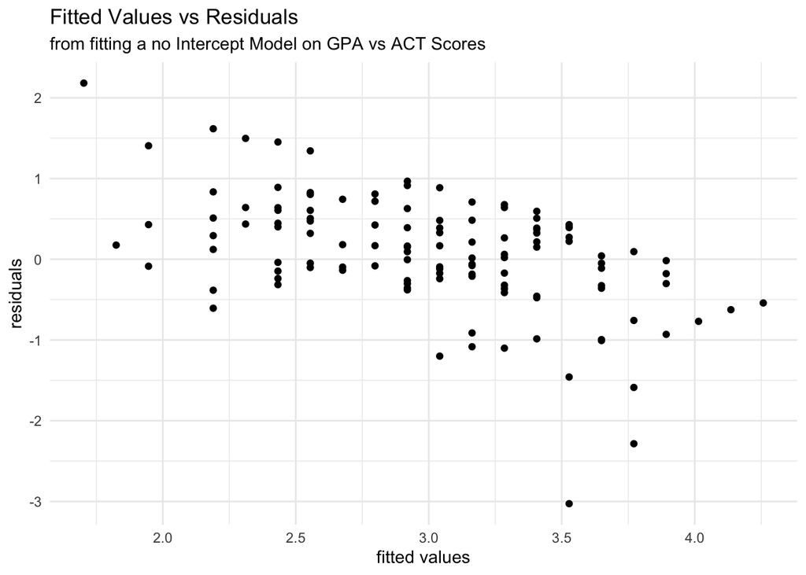

```r
gpa_no_intercept_model %>%
  ggplot(aes(preds, resids)) +
  geom_point() +
  labs(x = "fitted values",
       y = "residuals",
       title = "Fitted Values vs Residuals",
       subtitle = "from fitting a no Intercept Model on GPA vs ACT Scores")
```

There is a downward trend in the plot indicating that there is a nonconstant variance in the error terms. The model is not a good fit here.

3. Conduct a formal test for lack of fit of linear regression through the origin; use $\alpha = .005$. State the alternatives, decision rule and conclusion. What is the $P$-value of the test?

Answer: Let the null hypothesis be that $E[Y] = \beta_1X$ and the alternative that $E[Y] \neq \beta_1X$. Then

```r
lack.of.fit.origin.test(gpa, .005, TRUE)
```

[1] “P value: 0” [1] “At the alpha level of 0.005 the test statistic is 2.937 and the null hypothesis is rejected. There is evidence that the regression function is not linear.”

### Problem 16:

Refer to *Copier maintenance* Problem 1.20. Assume that linear regression through the origin model is appropriate.

1. Obtain the estimated regression function.

Answer:

```r
model = round(lm.fit.origin_manual(copier$x, copier$y), 3)
paste("Y = ", model, "X", sep = '')
```

[1] “Y = 14.947X”

2. Estimate $\beta_1$ with a $90$ percent confidence interval. Interpret your interval estimate.

Answer:

```r
b1.origin.conf.int(copier, .1)
```

[1] 14.567 15.328

The true value of $\beta_1$ lies between $14.567$ and $15.328$ with $90$ percent confidence.

3. Predict the service time on a new call in which six copiers are to be serviced. Use a $90$ percent prediction interval.

Answer:

```r
Yhat_pred_interval_origin(copier, 6, .1)
```

[1] 74.696 104.671

### Problem 17:

Refer to *Copier maintenance* Problem 4.16.

1. Plot the fitted regression line and the data. Does the linear regression through the origin appear to be a good fit here?

Answer:

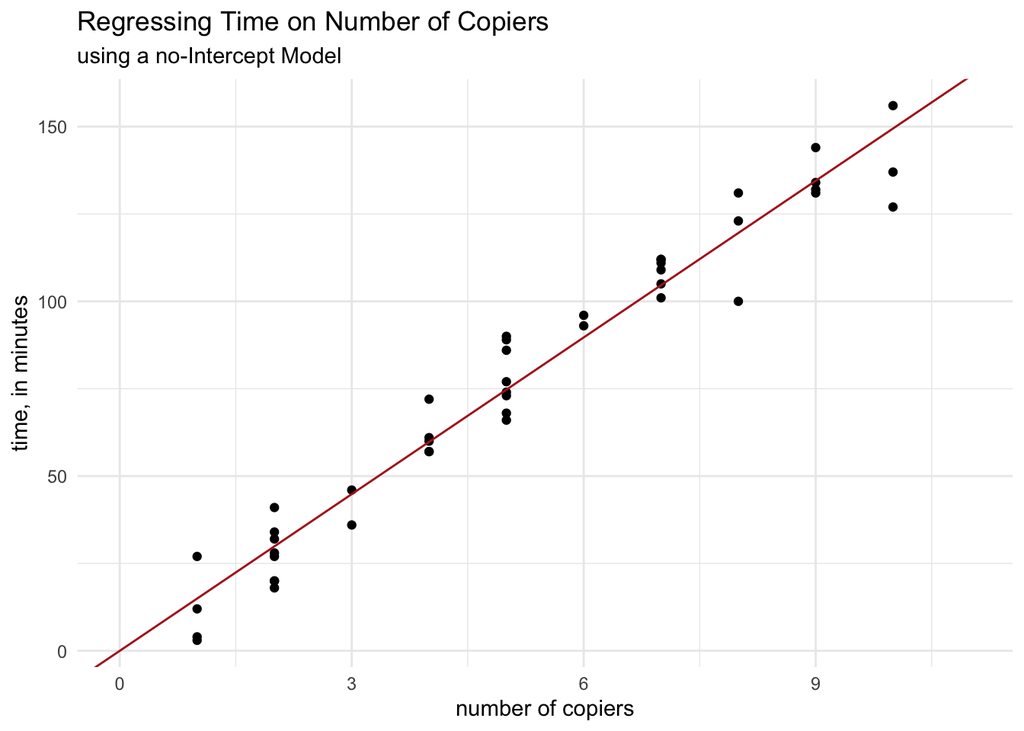

```r
model = lm.fit.origin_manual(copier$x, copier$y)

copier %>%
  ggplot(aes(x,y)) +
  geom_point() +
  geom_abline(intercept = 0, slope = model, color = "firebrick") +
  scale_x_continuous(limits = c(0, 11)) +
  labs(x = "number of copiers",
     y = "time, in minutes",
     title = "Regressing Time on Number of Copiers",
     subtitle = "using a no-Intercept Model")
```

The linear regression through the origin appears to be a good fir here.

2. Obtain the residuals $e_i$. Do they sum to zero? Plot the residuals against the fitted values $\hat{Y}_i$. What conclusions can be drawn from your plot?

Answer:

```r
copier_no_intercept_model = copier %>%
  mutate(preds = model*x,
         resids = y - preds)

copier_no_intercept_model$resids %>% sum
```

[1] -5.862797

The residuals of the no-intercept model do not sum to zero.

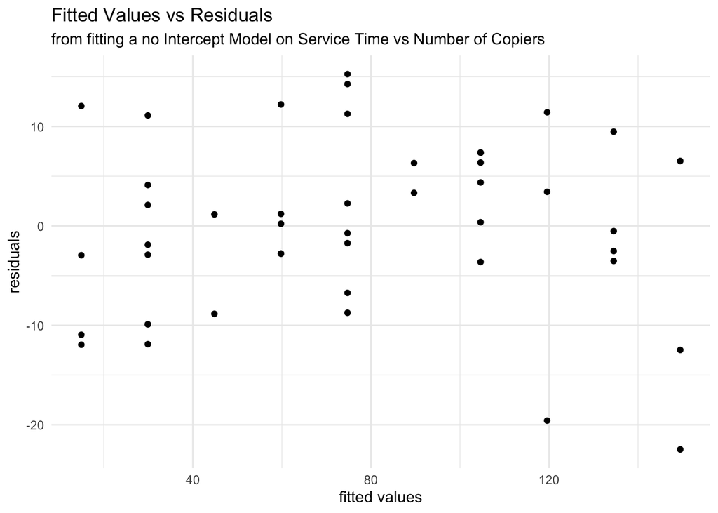

```r
copier_no_intercept_model %>%
  ggplot(aes(preds, resids)) +
  geom_point() +
  labs(x = "fitted values",
       y = "residuals",
       title = "Fitted Values vs Residuals",
       subtitle = "from fitting a no Intercept Model on Service Time vs Number of Copiers")
```

There does not appear to be any patterns in the plot, indicating that the variance of the error terms may be constant. This means that the model could be a good fit for the data.

3. Conduct a formal test for lack of fit of linear regression through the origin; use $\alpha = .01$. State the alternatives, decision rule and conclusion. What is the $P$-value of the test?

Answer: Let the null hypothesis be that $E[Y] = \beta_1X$ and the alternative be that $E[Y] \neq \beta_1X$. Then

```r
lack.of.fit.origin.test(copier, .01, TRUE)
```

[1] “P value: 0.564” [1] “At the alpha level of 0.01 the test statistic is 0.865 and the null hypothesis is rejected. There is evidence that the regression function is not linear.”

### Problem 18:

Refer to *Plastic hardness* Problem 1.22. Suppose that errors arise in $X$ because the laboratory technician is instructed to measure the hardness of the $i$th specimen ($Y_i$) at a prerecorded elapsed time ($X_i$), but the timing is imperfect so the true elapsed time varies at random from the prerecorded elapsed time. Will ordinary least squares estimates be biased here? Discuss.

Answer: Under the condition described, ordinary least squares estimates will not be biased. This is because error in timing is random and be encapsulated in the error term of the model.

### Problem 19:

Refer to *Grade point average* Problem 1.19. A new student earned a grade point average of $3.4$ in the freshman year.

1. Obtain a $90$ percent confidence interval for the students’ ACT test score. Interpret your confidence interval.

Answer:

```r
Xhat.conf.interval = function(data, Yhat, alpha = 0.01){

  model = lm.fit_manual(data$x, data$y)
  Xhat = (Yhat - model[1]) / model[2]
  pred = model[1] + model[2]*data$x
  MSE = sum((data$y - pred)^2)/(nrow(data)-2)
  temp = 1 + (1/nrow(data)) + ((Xhat - mean(data$x))^2/sum((data$x - mean(data$x))^2))
  s2_predX = MSE * temp / (model[2]^2)
  t = qt(1 - (alpha/2), nrow(data)-2)
  error = t*sqrt(s2_predX)
  lower = round(Xhat - error, 5)
  upper = round(Xhat + error, 5)
  return(c(lower, upper))
}

Xhat.conf.interval(gpa, 3.4, .1)
```

[1] 6.01315 60.22666

If a new student earns a grade point average of $3.4$, then their ACT score is estimated to be between $6.01315$ and $60.226$, with $90$ percent confidence.

2. Is criterion (4.33) as to the appropriateness of the approximate confidence interval met here?

Answer: Criterion (4.33) says that the approximate confidence interval is appropriate if the following quantity is small:
$$\frac{[t_{1 - \frac{\alpha}{2}}]^2 MSE}{b_1^2 \sum (X_i - \overline{X})^2}$$

```r
inverse.prediction.criterion = function(data, alpha){

  model = lm.fit_manual(data$x, data$y)
  pred = model[1] + model[2]*data$x
  MSE = sum((data$y - pred)^2)/(nrow(data) - 2)
  t = qt(1 - (alpha/2), nrow(data) - 2)

  quantity = round((t^2 * MSE) / (model[2]^2 * sum((data$x - mean(data$x))^2)), 3)

  if(quantity < .1){
    paste("The criterion equals", quantity,
          "which is small and so the confidence interval is appropriate", sep = ' ')
  }
  else{
    paste("The criterion equals", quantity,
          "which is large and so the confidence interval is not appropriate", sep = ' ')
  }
}
inverse.prediction.criterion(gpa, .1)
```

[1] “The criterion equals 0.297 which is large and so the confidence interval is not appropriate”

### Problem 20:

Refer to *Plastic hardness* Problem 1.22. The measurement of a new test item showed $238$ Brinell units of hardness.

1. Obtain a $99$ percent confidence interval for the elapsed time before the hardness was measured. Interpret your confidence interval.

Answer:

```r
Xhat.conf.interval(plastic, 238, .01)
```

[1] 29.16920 39.05815

If a new test item showed $238$ Brinell units of hardness, it can be said with $99$ percent confidence that the elapsed time between the hardness was measured lies between $29.16920$ and $39.05815$.

2. Is criterion (4.33) as to the appropriateness of the approximate confidence interval met here?

Answer:

```r
inverse.prediction.criterion(plastic, .01)
```

[1] “The criterion equals 0.017 which is small and so the confidence interval is appropriate”

### Problem 21:

When the predictor variable is coded that $\overline{X} = 0$ and the normal error regression model applies, are $b_0$ and $b_1$ independent? Are the joint confidence intervals for $\beta_0$ and $\beta_1$ then independent?

Answer: When the predictor variable is coded such that $\overline{X} = 0$, and the normal error regression model is applied, then $b_0$ and $b_1$ are independent. This comes from the covariance of $b_0$ and $b_1$, which is
$$\sigma[b_0, b_1] = -\overline{X}\sigma^2[b_1]$$
When the covariance is $0$, that means $b_0$ and $b_1$ are independent. However, it does not mean that the joint confidence intervals for $\beta_0$ and $\beta_1$ are then independent as well, since each of the confidence intervals depend on a single multiplier for the standard deviation.

### Problem 22:

Derive an extension of the Bonferroni inequality (4.2a) for the case of three statements, each with statement confidence coefficients $1-\alpha$.

Answer: Let $A_3$ denote the event that the third statement is not correct, and $\overline{B}$ be the event the first two statements are correct, or $\overline{A}_1 \cap \overline{A}_2$. Then
$$P(\overline{B} \cap \overline{A}_3) = P(\overline{A}_1 \cap \overline{A}_2 \cap \overline{A}_3) \geq 1 - 2\alpha - \alpha = 1 - 3\alpha$$

### Problem 23:

Show that for the fitted least squares regression line through the origin (4.15), $\sum X_ie_i = 0$.

Answer: For the fitted least squares regression line through the origin, the estimator of $\beta_1$ is obtained by minimizing
$$Q = \sum (Y_i - \beta_1X_i)^2$$
resulting in the normal equation
$$\sum X_i(Y_i - b_1X_i) = 0$$
The regression model under this framework is
$$Y_i = \beta_1X_i + \varepsilon_i$$
and so by substituting the estimates in for each variable and rearranging,
$$e_i = Y_i - b_1X_i$$
This can be plugged into the normal equation:
$$\sum X_i(Y_i - b_1X_i) = \sum X_ie_i = 0$$

### Problem 24:

Show that $\hat{Y}$ as defined in (4.15) for linear regression through the origin is an unbiased estimator of $E[Y]$.

Answer: To show that $\hat{Y}$ is an unbiased estimator of $E[Y]$, show that $E[\hat{Y}] = E[Y]$. Now, since the framework is linear regression through the origin, it is known that
$$\hat{Y} = b_1X$$
and so
$$E[\hat{Y}] = E[b_1X] = XE[b_1] = X\beta_1 = E[Y]$$

### Problem 25:

Derive the formula for $s^2[\hat{Y}_h]$ for linear regression through the origin.

Answer: Since
$$\hat{Y}_h = b_1X_h$$
then
$$\sigma^2[\hat{Y}_h] = \sigma^2[b_1X_h] = X_h^2\sigma^2[b_1] = \frac{X_h^2 \sigma^2}{\sum X_i^2}$$
Now replace $\sigma$ with $MSE$ for the estimate of $\sigma^2[\hat{Y}_h]$ and so
$$s^2[\hat{Y}_h] = \frac{X_h^2 MSE}{\sum X_i^2}$$

### Problem 26:

Refer to the *CDI* dataset in Appendix C.2 and Project 1.43. Consider the regression relation of number of active physicians to total population.

1. Obtain Bonferroni joint confidence intervals for $\beta_0$ and $\beta_1$, using a $95$ percent family confidence coefficient.

Answer:

```r
cdi_cols = c('ID', 'county', 'state', 'area', 'total_pop', 'perc_pop_18to34',
             'perc_pop_65plus', 'num_physicians', 'num_hosp_beds', 'total_crimes',
             'perc_hs_grads', 'perc_bach', 'perc_below_poverty', 'perc_unemploy',
             'per_capita_income', 'total_personal_income', 'geographic_region')
cdi_colclasses = c('integer', 'character', 'character', rep('numeric', 13), 'factor')
cdi = read.csv('APPENC02.txt', sep = '', header = FALSE,
                  col.names = cdi_cols,
                  colClasses = cdi_colclasses)

cdi_relevant = cdi %>% select(x = total_pop, y = num_physicians)
bonferroni.joint.ci(cdi_relevant, .05)
```

[1] “At the alpha level of 0.05 the Bonferroni joint confidence intervals are: -188.783 <= b0 <= -32.486 and 0.003 <= b1 <= 0.003”

2. An investigator has suggested that $\beta_0$ should be $-100$ and $\beta_1$ should be $.0028$. Do the joint confidence intervals in part (a) support this view? Discuss.

Answer: The joint confidence intervals in part (a) support this view as both estimates fall witin the confidence limits found.

3. It is desired to estimate the expected number of active physicians for countries with total population of $X = 500$, $1,000$, $5,000$ thousands with family confidence coefficient $.90$. Which procedure, the Working-Hotelling or the Bonferroni, is more efficient here?

Answer:

```r
working.hotelling.coef(.1, nrow(cdi_relevant))
```

[1] “The Working-Hotelling procedure gives an estimate of 2.152 for the multiple of the estimated standard deviation”

```r
bonferroni.coef(.1, 3, nrow(cdi_relevant))
```

[1] “The Bonferroni procedure gives an estimate of 2.135 for the multiple of the estimated standard deviation”

The Bonferroni procedure is more efficient here since the multiplier is smaller than that under the Working-Hotelling procedure.

4. Obtain the family of interval estimates required in part (c), using the more efficient procedure. Interpret your confidence intervals.

Answer:

```r
family.pred.interval(cdi_relevant, .1, 3, 500, "Bonferroni")
```

[1] “Using a 10 percent alpha value and the Bonferroni procedure, Y_h is estimated to lie between -183.384 and -35.09”

```r
family.pred.interval(cdi_relevant, .1, 3, 1000, "Bonferroni")
```

[1] “Using a 10 percent alpha value and the Bonferroni procedure, Y_h is estimated to lie between -181.958 and -33.721”

```r
family.pred.interval(cdi_relevant, .1, 3, 5000, "Bonferroni")
```

[1] “Using a 10 percent alpha value and the Bonferroni procedure, Y_h is estimated to lie between -170.552 and -22.764”

### Problem 27:

Refer to the *SENIC* dataset in Appendix C.1 and Project 1.45. Consider the regression relation of average length of stay to infection risk.

1. Obtain Bonferroni join confidence intervals for $\beta_0$ and $\beta_1$, using a $90$ percent family confidence coefficient.

Answer:

```r
senic_cols = c('ID', 'length_stay', 'age', 'infection_risk', 'culturing_ratio',
               'chest_xray_ratio', 'num_beds', 'med_school_aff', 'region',
               'avg_daily_census', 'num_nurses', 'available_facilities')
senic_colclasses = c(rep('numeric', 6), rep('factor', 2), rep('numeric', 3))
senic = read.csv('APPENC01.txt', sep = '', header = FALSE,
                  col.names = senic_cols,
                  colClasses = senic_colclasses)
senic_relevant = senic %>% select(x = infection_risk, y = length_stay)

bonferroni.joint.ci(senic_relevant, .1)
```

[1] “At the alpha level of 0.1 the Bonferroni joint confidence intervals are: 5.304 <= b0 <= 7.37 and 0.534 <= b1 <= 0.987”

2. A researcher suggested that $\beta_0$ should be approximately $7$ and $\beta_1$ should be approximately $1$. Do the joint intervals in part (a) support this expectation? Discuss.

Answer: The joint intervals in part (a) do not support this expectation since $\beta_1$ falls outside the interval calculated.

3. It is desired to estimate the expected hospital stay for persons with infection risks $X=2$, $3$, $4$, $5$ with family confidence coefficient $.95$. Which procedure, the Working-Hotelling or the Bonferroni, is more efficient here?

Answer:

```r
working.hotelling.coef(.05, nrow(senic_relevant))
```

[1] “The Working-Hotelling procedure gives an estimate of 2.481 for the multiple of the estimated standard deviation”

```r
bonferroni.coef(.05, 4, nrow(senic_relevant))
```

[1] “The Bonferroni procedure gives an estimate of 2.539 for the multiple of the estimated standard deviation”

The Working-Hotelling procedure is more efficient here due to the smaller multiplier.

4. Obtain the family of interval estimates required in part (c), using the more efficient procedure. Interpret your confidence intervals.

Answer:

```r
working.hotelling.reg.band(senic_relevant, .05, 2)
```

[1] “Using a 5 percent alpha value and the Working-Hotelling procedure, Y_h is estimated to lie between 7.089 and 8.626”

```r
working.hotelling.reg.band(senic_relevant, .05, 3)
```

[1] “Using a 5 percent alpha value and the Working-Hotelling procedure, Y_h is estimated to lie between 8.078 and 9.158”

```r
working.hotelling.reg.band(senic_relevant, .05, 4)
```

[1] “Using a 5 percent alpha value and the Working-Hotelling procedure, Y_h is estimated to lie between 8.986 and 9.771”

```r
working.hotelling.reg.band(senic_relevant, .05, 5)
```

[1] “Using a 5 percent alpha value and the Working-Hotelling procedure, Y_h is estimated to lie between 9.718 and 10.56”